## Cartão - Proporção de usuários for sexo e faixa-etária, A.1

### Conceituação

Proporção de usuários de Protocolo Clínico e Diretrizes Terapêuticas - PCDT por faixa-etária e sexo.

### Interpretação

- expressa uma relação quantitativa entre sexo e faixa-etária em anos.
- As faixa-etária de cada usuário é obtida a partir do ano de nascimento mais frequente registrado no Sistema de Informação Ambulatorial.
- Se igual a 100, todos os usuários são homens ou mulheres de uma dada faixa-etária.

### Usos

- Analisar variações na distribuição da população por sexo e faixa-etária.
- Subsidiar processos de planejamento, gestão e avaliação de políticas públicas de medicamentos.
- Identificar necessidades de estudos sobre os fatores condicionantes das variações encontradas.

### Limitações

Trata-se de registros administrativos de informações ambulatoriais, logo, não é carantida a informação do ponto de vista do registro civil de cada paciente.

A idade é calculada em anos com base no ano de nascimento mais frequente em relação ao número de registros no Sistema de Informações Ambulatoriais. O cálculo desejável decorreira da data de nascimento.

### Fonte

- DATASUS/MS - Ministério da Saúde, Departamento de Informática do SUS [ftp://ftp.datasus.gov.br/dissemin/publicos/SIASUS/200801_/Dados/].
- IBGE - Instituto Brasileiro de Geografia e Estatística [https://educa.ibge.gov.br/jovens/conheca-o-brasil/populacao/18318-piramide-etaria.html]
- RIPSA - Rede Intergerencial de Informações em Saúde. Razão de sexos [http://fichas.ripsa.org.br/2012/a-2/?l=pt_BR]

### Métodos de Cálculo

Fórmula geral:

$$P_{SF} \frac{n_{SF}}{T}\times 100$$

onde $P_{SF}$ é a proporção da respectiva combinação de sexo $S$ e faixa-etária $F$, cujos domínios são, respectivamente

$$S=\{feminino, masculino\}$$

$$F=\left \{\begin{array}{ccccc}
00-04 & 05-09 & 10-14 & 15-19 & 20-24\\
25-29 & 30-34 & 35-39 & 40-44 & 45-49\\
50-54 & 55-59 & 60-64 & 65-69 & 70-74\\
75-79 & 80-84 & 85-89 & 90+ &
\end{array} \right \}$$

$n_{SF}$ é o número de usuários do sexo e da faixa etária e $T$ é o total de usuários do PCDT, obtido por $T=\sum{n_{SF}}$.

### Categorias Sugeridas para Análise

- Unidade geográfica: Brasil, Grandes Regiões, Estados, Distrito Federal e Regiões Metropolitanas.
- Município de residência
- Medicamento

### Dados Estatísticos e Comentários

Visualizar no painel [SABEIS](https://labxss.shinyapps.io/sabeis_pcdt2/) > Explore.

### Notas

Realizado conforme metodologia RIPSA. Vide a seção *fonte*.

### Visualização

Pirâmide etária.

### Conjunto de dados e Código-fonte

#### Pré-requisitos

Baixe o arquivo **db_sabeis.tf_pcdt_paciente.csv** na pasta [dataset](https://github.com/labxss/sabeis_pcdt/tree/master/dataset/csv).

Certifique-se de que os pacotes R abaixo estejam instalados.

```r
library(pyramid)
library(knitr)
```

#### R script

Lê arquivo csv e ajusta para o formato percentual.

Ajuste o caminho do arquivo para o diretório onde baixou.

```r
tf_pcdt_paciente = read.csv(file = 'db_sabeis.tf_pcdt_paciente.csv')

# ajusta para o formato percentual
tf_pcdt_paciente$qt_paciente_m =
  tf_pcdt_paciente$qt_paciente_m/tf_pcdt_paciente$qt_registros_pcdt*100

tf_pcdt_paciente$qt_paciente_f =
  tf_pcdt_paciente$qt_paciente_f/tf_pcdt_paciente$qt_registros_pcdt*100
```

Amostra da tabela de entrada.

|  | qt_paciente_m | qt_paciente_f | sg_faixa_etaria |
| --- | --- | --- | --- |
| 9 | 3.754098 | 4.491803 | 40-44 |
| 10 | 4.114754 | 4.901639 | 45-49 |
| 11 | 4.754098 | 6.557377 | 50-54 |
| 12 | 5.655738 | 6.393443 | 55-59 |
| 13 | 4.836066 | 6.704918 | 60-64 |

Plota a pirâmide etária com o pacote [pyramid](https://cran.r-project.org/web/packages/pyramid/pyramid.pdf).

Observe o filtro **co_pcdt**, o qual extrai dados apenas para um PCDT.

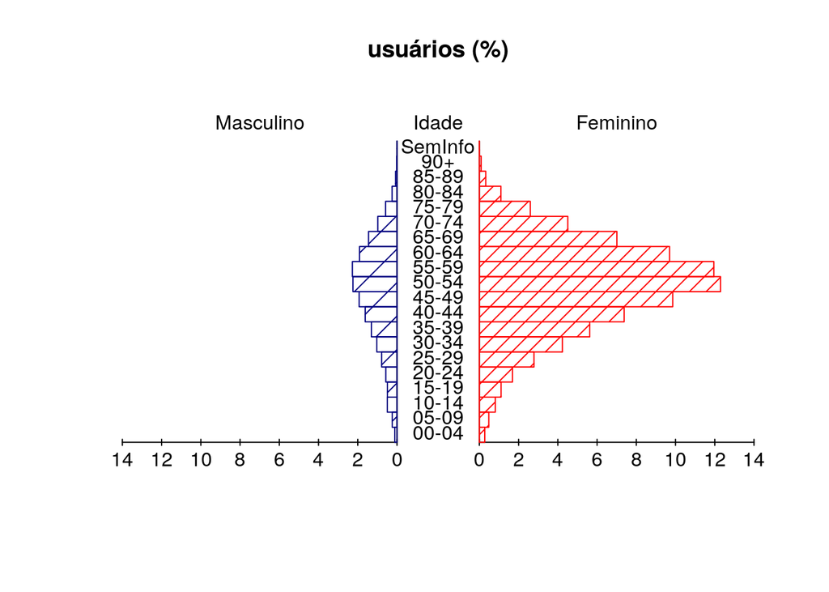

```r
pyramid(
      subset(tf_pcdt_paciente, co_pcdt == 10)[,c(2,3,6)],
      Llab="Masculino",Rlab="Feminino",
      Lcol="navy",
      Ldens=5,
      Rcol="red",
      Rdens=10, GL=FALSE, Clab = "Idade", main = "usuários (%)"
    )
```